# Examples

```r
eg.cov <- matrix(c(1,-2, 0, -2, 5, 0, 0, 0,2), nrow=3, byrow=TRUE)
eg.eigen <- eigen(eg.cov)
sqrt(eg.eigen$values) * eg.eigen$vectors
```

| -0.9238795 | 0.0000000 | 2.2304425 |
| --- | --- | --- |
| 1.3065630 | 0.0000000 | 0.5411961 |
| 0.0000000 | 0.4142136 | 0.0000000 |

```r
eg.cov
```

| 1 | -2 | 0 |
| --- | --- | --- |
| -2 | 5 | 0 |
| 0 | 0 | 2 |

```r
sqrt(round(eg.eigen$values,2)) * round(eg.eigen$vectors,3)
```

| -0.9247685 | 0.0000000 | 2.2310343 |
| --- | --- | --- |
| 1.3067333 | 0.0000000 | 0.5416438 |
| 0.0000000 | 0.4123106 | 0.0000000 |

# Q1

```r
# a
q1.cov <- matrix(c(5,2,2,2),nrow=2, byrow=TRUE)
q1.cov


q1.cov_eigen <- eigen(q1.cov)
q1.cov_eigen

print('Proportion:')
for (s in q1.cov_eigen$values) {
  print(s / sum(q1.cov_eigen$values))
}
```

| 5 | 2 |
| --- | --- |
| 2 | 2 |

```
eigen() decomposition
$values
[1] 6 1

$vectors
           [,1]       [,2]
[1,] -0.8944272  0.4472136
[2,] -0.4472136 -0.8944272
```

```
[1] "Proportion:"
[1] 0.8571429
[1] 0.1428571
```

```r
# b
q1.corr <- cov2cor(q1.cov)
q1.corr

q1.corr_eigen <- eigen(q1.corr)
q1.corr_eigen

print('Proportion:')
for (s in q1.corr_eigen$values) {
  print(s / sum(q1.corr_eigen$values))
}

q1.corr_y1z1 <- q1.corr_eigen$vectors[1,1]*sqrt(q1.corr_eigen$values[1])
q1.corr_y1z2 <- q1.corr_eigen$vectors[2,1]*sqrt(q1.corr_eigen$values[1])
q1.corr_y2z1 <- q1.corr_eigen$vectors[1,2]*sqrt(q1.corr_eigen$values[2])

q1.corr_y1z1
q1.corr_y1z2
q1.corr_y2z1
```

| 1.0000000 | 0.6324555 |
| --- | --- |
| 0.6324555 | 1.0000000 |

```
eigen() decomposition
$values
[1] 1.6324555 0.3675445

$vectors
          [,1]       [,2]
[1,] 0.7071068 -0.7071068
[2,] 0.7071068  0.7071068
```

```
[1] "Proportion:"
[1] 0.8162278
[1] 0.1837722
```

0.903453245064092

0.903453245064092

-0.428686638447202

[Note! The variance-covariance matrix of the standardized data is equal to the correlation matrix for the unstandardized data. Therefore, principal component analysis using the standardized data is equivalent to principal component analysis using the correlation matrix.](https://online.stat.psu.edu/stat505/book/export/html/670#:~:text=for%20variable%20j-,Note!,analysis%20using%20the%20correlation%20matrix.)

- That why it's different if it's not standardized

The two (standardized) variables contribute equally to the pc in b(i). The two variables contribute unequally to the principal components in a because of their unequal vairances.

# Q2

```r
# a
q2.cov <- matrix(c(7476.45, 303.62,303.62,26.19),nrow=2, byrow=TRUE)
q2.cov

q2.cov_eigen <- eigen(q2.cov)
q2.cov_eigen

print('Proportion:')
for (s in q2.cov_eigen$values) {
  print(s / sum(q2.cov_eigen$values))
}
```

| 7476.45 | 303.62 |
| --- | --- |
| 303.62 | 26.19 |

```
eigen() decomposition
$values
[1] 7488.80293   13.83707

$vectors
            [,1]        [,2]
[1,] -0.99917337  0.04065185
[2,] -0.04065185 -0.99917337
```

```
[1] "Proportion:"
[1] 0.9981557
[1] 0.001844294
```

```r
# b
q2.cov_y1z1 <- q2.cov_eigen$vectors[1,1]*sqrt(q2.cov_eigen$values[1]) / sqrt(q2.cov[1,1])
q2.cov_y1z2 <- q2.cov_eigen$vectors[2,1]*sqrt(q2.cov_eigen$values[1]) / sqrt(q2.cov[2,2])

q2.cov_y1z1
q2.cov_y1z2
```

-0.999998470745409

-0.687414617862137

the first component is completely determined by x1=sales since its variance is approx 285 times of x2=profits

```r
# c
q2.corr <- cov2cor(q2.cov)
q2.corr

q2.corr.eigen <- eigen(q2.corr)
q2.corr.eigen

print('Proportion:')
for (s in q2.corr.eigen$values) {
  print(s / sum(q2.corr.eigen$values))
}

q2.corr_y1z1 <- q2.corr.eigen$vectors[1,1]*sqrt(q2.corr.eigen$values[1])
q2.corr_y1z2 <- q2.corr.eigen$vectors[2,1]*sqrt(q2.corr.eigen$values[1])

q2.corr_y1z1
q2.corr_y1z2
```

| 1.0000000 | 0.6861434 |
| --- | --- |
| 0.6861434 | 1.0000000 |

```
eigen() decomposition
$values
[1] 1.6861434 0.3138566

$vectors
          [,1]       [,2]
[1,] 0.7071068 -0.7071068
[2,] 0.7071068  0.7071068
```

```
[1] "Proportion:"
[1] 0.8430717
[1] 0.1569283
```

0.918189368102989

0.918189368102989

The standardized "sales" and "profits" contribute equally to the first principal component. The variance for x1 and x2 has a huge difference, then the pc will be affected of the whichever variable that having a larger range. Hence it will be better to use the standardized.

# Q3

```r
path <- '../data/radiotherapy.csv'
q3 <- read.csv(path, fileEncoding="UTF-8-BOM")
```

```r
q3.cov <- cov(q3)
q3.cor <- cor(q3)
q3.cor
```

|  | x1 | x2 | x3 | x4 | x5 | x6 |
| --- | --- | --- | --- | --- | --- | --- |
| x1 | 1.00000000 | 0.55143669 | 0.3615773 | 0.38627479 | 0.53655840 | 0.07897812 |
| x2 | 0.55143669 | 1.00000000 | 0.1874625 | 0.45544470 | 0.53500626 | -0.03420407 |
| x3 | 0.36157729 | 0.18746250 | 1.0000000 | 0.34638617 | 0.49577944 | 0.15696886 |
| x4 | 0.38627479 | 0.45544470 | 0.3463862 | 1.00000000 | 0.70464665 | 0.07073348 |
| x5 | 0.53655840 | 0.53500626 | 0.4957794 | 0.70464665 | 1.00000000 | -0.01023155 |
| x6 | 0.07897812 | -0.03420407 | 0.1569689 | 0.07073348 | -0.01023155 | 1.00000000 |

```r
q3.cor.eigen <- eigen(q3.cor)
q3.cor.eigen

print('Proportion:')
for (s in q3.cor.eigen$values) {
  print(s / sum(q3.cor.eigen$values))
}
```

```
eigen() decomposition
$values
[1] 2.8643078 1.0764496 0.7776412 0.6503143 0.3880318 0.2432554

$vectors
            [,1]        [,2]       [,3]        [,4]        [,5]        [,6]
[1,] -0.44485828 -0.02665962 -0.3393295  0.55114851  0.60085058  0.14649150
[2,] -0.42929971 -0.29173810 -0.4986071  0.06136723 -0.68729718  0.07640845
[3,] -0.35877306  0.38013490  0.6281571  0.42105976 -0.33183937  0.21163500
[4,] -0.46285372 -0.02095878  0.1245847 -0.66560356  0.20741295  0.53268901
[5,] -0.52127626 -0.07369010  0.2033387 -0.20052634  0.10317525 -0.79412736
[6,] -0.05587718  0.87396001 -0.4298804 -0.17871526 -0.05308994 -0.11626161
```

```
[1] "Proportion:"
[1] 0.4773846
[1] 0.1794083
[1] 0.1296069
[1] 0.1083857
[1] 0.06467196
[1] 0.04054257
```

```r
q3.pc <- princomp(scale(q3))
```

Number of important pc is 4, which account for 89% of the variation. It is not possible to summarize the radiotherapy data with single reaction index component.

```r
q3.pc$loadings
```

```
Loadings:
   Comp.1 Comp.2 Comp.3 Comp.4 Comp.5 Comp.6
x1  0.445         0.339  0.551  0.601  0.146
x2  0.429  0.292  0.499        -0.687
x3  0.359 -0.380 -0.628  0.421 -0.332  0.212
x4  0.463        -0.125 -0.666  0.207  0.533
x5  0.521        -0.203 -0.201  0.103 -0.794
x6        -0.874  0.430 -0.179        -0.116

               Comp.1 Comp.2 Comp.3 Comp.4 Comp.5 Comp.6
SS loadings     1.000  1.000  1.000  1.000  1.000  1.000
Proportion Var  0.167  0.167  0.167  0.167  0.167  0.167
Cumulative Var  0.167  0.333  0.500  0.667  0.833  1.000
```

```r
q3.scale = scale(q3)
q3.x1 = as.matrix(q3) %*% q3.pc$loadings[,1]
```

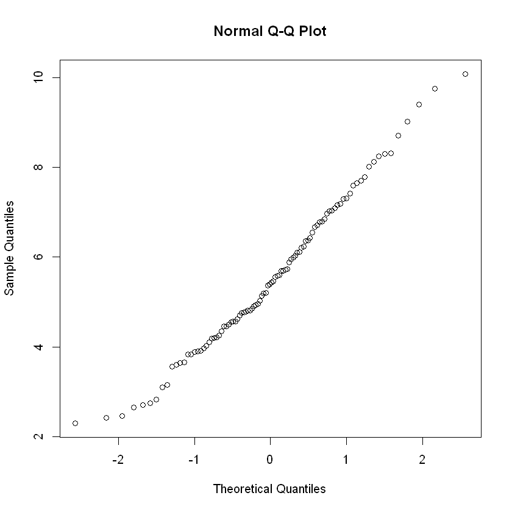

```r
qqnorm(q3.x1)
```